# Gráficos de R, en Python

Una alternativa obvia es utilizar [Rpy](http://rpy.sourceforge.net/), que empotra a R dentro del proceso Python. Es simplemente una interfaz a un entorno de ejecución de R. => esto no es muy optimo. Pero se peude ejecutar alguna biblioteca de R en python.

NOTA: Esto es diferente de tener un Notebook Jupyter con kernels de R!

** gg : viene del libro grammar of graphics de Leland Wilkinson.

## Utilizando ggplot2

La biblioteca ggplot en Python permite utilizar la biblioteca de gráficos ggplot2 de R, que intenta combinar lo mejor del paquete básicoy la biblioteca lattice de R.

Para instalarlo:

```
pip install ggplot
```

NOTA: La biblioteca no está implementada 100%.

```python
import statsmodels.api as sm #get_rdataset ; del paquete Ecdat cargue el dataset Wages1. con esto se puede utilizar un
#dataset de R en Python.
wages = sm.datasets.get_rdataset("Wages1", "Ecdat")
print wages.__doc__
data = wages.data # ya se carga el dataset en Python.
data.head()
```

```
+----------+-------------------+
| Wages1   | R Documentation   |
+----------+-------------------+

Wages, Experience and Schooling
-------------------------------

Description
~~~~~~~~~~~

a panel of 595 observations from 1976 to 1982

*number of observations* : 3294

*observation* : individuals

*country* : United States

Usage
~~~~~

::

    data(Wages1)

Format
~~~~~~

A time serie containing :

exper
    experience in years

sex
    a factor with levels (male,female)

school
    years of schooling

wage
    wage (in 1980 \\$) per hour

References
~~~~~~~~~~

Verbeek, Marno (2004) *A guide to modern econometrics*, John Wiley and
Sons,
`http://www.econ.kuleuven.ac.be/GME <http://www.econ.kuleuven.ac.be/GME>`__.

See Also
~~~~~~~~

``Index.Source``, ``Index.Economics``, ``Index.Econometrics``,
``Index.Observations``,

``Index.Time.Series``
```

|  | exper | sex | school | wage |
| --- | --- | --- | --- | --- |
| 0 | 9 | female | 13 | 6.315296 |
| 1 | 12 | female | 12 | 5.479770 |
| 2 | 11 | female | 11 | 3.642170 |
| 3 | 9 | female | 14 | 4.593337 |
| 4 | 8 | female | 14 | 2.418157 |

## La filosofía de ggplot

Hay dos maneras de hacer gráficos en ggplot2:

- qplot() – quick plots => Esto es el plot de R.
- ggplot() – control total de lo que se dibuja => Esto ya si es estilo ggplot.

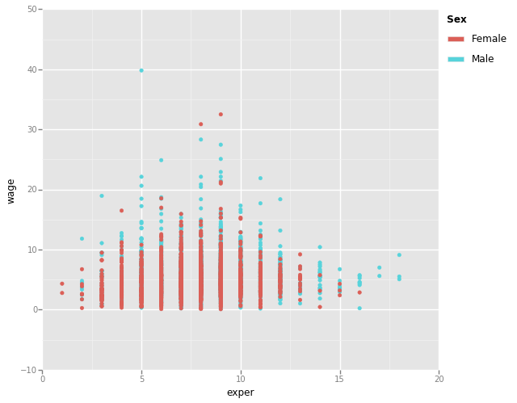

```python
%matplotlib inline
from ggplot import *
qplot(data=data, x="exper", y="wage", color="sex")
```

```
stat_bin: binwidth defaulted to range/30.
    Use 'binwidth = x' to adjust this.
```

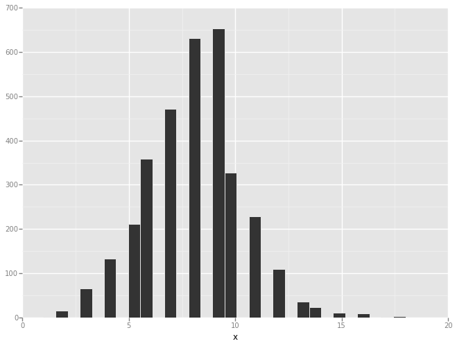

```python
qplot(data["exper"])
```

Al crear un gráfico, podemos especificar aes() y los datos.

```python
p = ggplot(aes(x='exper', y='wage'), data=data)
# en ggplot, se le asocia eldataframe y se configura una serie de pasos. Con esto aun no se dibuja nada. Se le indica
# cuales son las columnas que vas a utilizar.
```

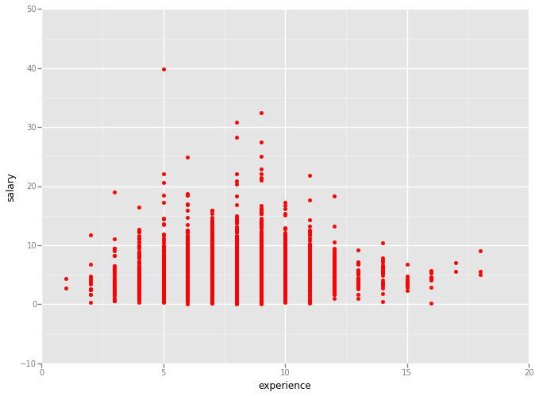

```python
p + xlab("experience") + ylab("salary")+ geom_point(color = "red")
# para añadir capas al objeto se suman, hemos añadido los nombres de las etiquetas...
```

## Utilizando RPlot

RPlot es una biblioteca integrada en pandas que trata de implementar los "gráficos Trellis" que son muy útiles para observar la relación entre variables. Estos gráficos en R originalmente se implementaron en el paquete lattice.

** Rplot => esta muerto...

```python
import pandas as pd
import pandas.tools.rplot as rplot
```

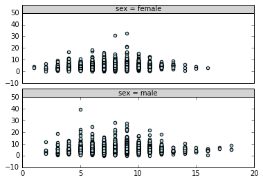

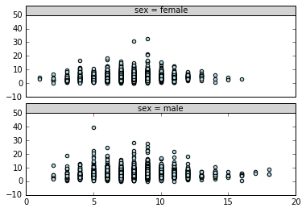

```python
plot = rplot.RPlot(data, x='exper', y='wage')
plot.add(rplot.TrellisGrid(['sex', "."]))
plot.add(rplot.GeomScatter())
plot.render()
```